[OHI British Columbia](http://www.ohibc.org/) | [OHI Science](http://ohi-science.org) | [Citation policy](https://github.com/OHI-Science/ohiprep/releases)

# OHIBC: Ocean Acidification Pressure layers prep

Compiled on Mon Jul 31 12:19:07 2017 by ohara

# 1 Summary

This layer will determine ocean acidification values from the global rate of change layers; these layers already scale OA pressures appropriately. The rescaling is based on the changes in aragonite saturation state according to:

$$\Delta \Omega_{year} = \frac{(\Omega_{base} - \Omega_{year})}{(\Omega_{base} - 1)}$$

In the global analysis, pressures for 2011-2016 are available with this rescaling; however, for this OHIBC analysis, we will begin with the global rasters for annual mean aragonite saturation state values, crop to BC, interpolate using inverse distance weighting, and then reproject to approx 1 km resolution (from CHI).

# 2 Data

This script captures OA spatial data from the OHI Global assessments and determines scores for each OHIBC region.

The OA data layers for OHI Global are located on Mazu.

## 2.1 Data Source for global OA layer:

# 3 Methods

## 3.1 Create Mollweide OHIBC regions

Since the pressures layers are created in Mollweide projection for OHI Global, we will create a Mollweide version of the OHIBC regions for defining the analysis. This allows us to avoid reprojecting the raster and adding another layer of resampling.

## 3.2 Collect and crop OA pressures for BC

Each global raster is cropped to the same extents as the BC Mollweide raster and saved to git-annex/bcprep. This is done for all rasters 1958-2020. From this, a subset will be copied to GitHub for use in the actual calculations.

Note also that the interpolated cells raster is in this same location and will also be copied to GitHub.

### 3.2.1 Animate OA pressure rasters

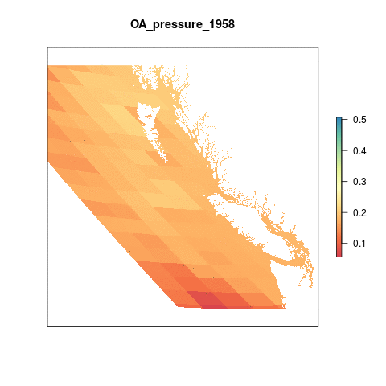

## 3.3 Calculate mean pressures per region

For OHIBC we will focus on the years 2000-2017; these pressure layers will be copied from Mazu to GitHub for easy availability. The gapfilling raster will also be copied for reference.

For each year, pull in the pressure raster and run zonal stats to find mean pressure in each region for each year.

|  | rgn_id | year | pressure |
| --- | --- | --- | --- |
| 1 | 1 | 2000 | 0.3914 |
| 2 | 2 | 2000 | 0.3852 |
| 3 | 3 | 2000 | 0.377 |
| 4 | 4 | 2000 | 0.3693 |
| 5 | 5 | 2000 | 0.3589 |
| 6 | 6 | 2000 | 0.3668 |
| 7 | 7 | 2000 | 0.3416 |
| 8 | 8 | 2000 | 0.3814 |
| 9 | 1 | 2001 | 0.3471 |
| 10 | 2 | 2001 | 0.3373 |

[output cut: 134 more lines]

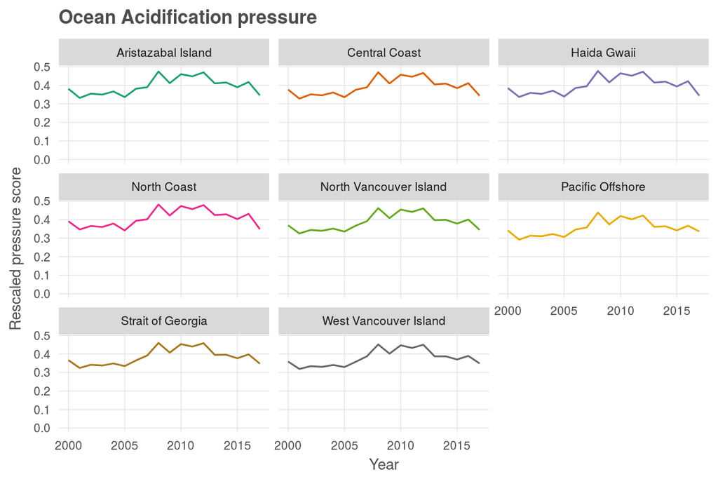

## 3.4 Calculate gapfilling proportional areas

Using a pressure raster prior to the interpolation step, we resample at the 934 m resolution, replacing cells with non-NA values with a 1 and cells with NA value with -1.

Taking a mean of this layer by OHIBC region will give a value between -1 (100% gapfill) and +1 (0% gapfill).

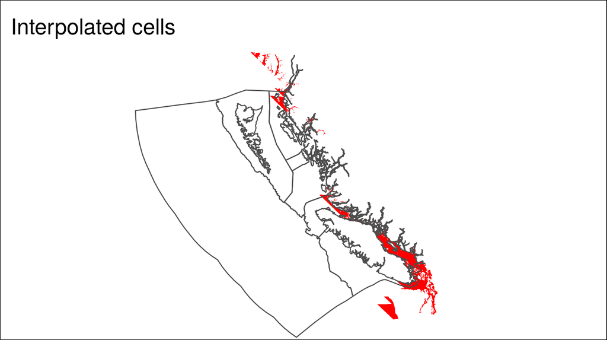

|  | rgn_id | pct_gf |
| --- | --- | --- |
| 1 | 1 | 14.6 |
| 2 | 2 | 0 |
| 3 | 3 | 1.6 |
| 4 | 4 | 23.5 |
| 5 | 5 | 3.9 |
| 6 | 6 | 86.9 |
| 7 | 7 | 0 |
| 8 | 8 | 0 |

# 4 Provenance

- *Run ID: 7 (01a5937); run tag: “standard run”*
- *Run elapsed time: 80.403 seconds; run memory usage: 4772.8 MB*
- *System info:*
  - *System: Linux, Release: 4.4.0-57-generic. Machine: x86_64. User: ohara.*
  - *R version: R version 3.4.1 (2017-06-30), Platform: x86_64-pc-linux-gnu, Running under: Ubuntu 14.04.5 LTS.*
  - *Attached base packages: stats, graphics, grDevices, utils, datasets, methods, base*
  - *Other attached packages: bindrcpp_0.2, provRmd_0.1.1, stringr_1.2.0, RColorBrewer_1.1-2, dplyr_0.7.1, purrr_0.2.2, readr_1.1.0, tidyr_0.6.2, tibble_1.3.3, ggplot2_2.2.1.9000, tidyverse_1.1.1, raster_2.5-8, rgdal_1.2-8, sp_1.2-5*

[figure not shown]

[output not shown]

[output cut: 262 more lines]